# Como criar uma wordcloud no formato que quiser

[figure not shown]

## O que é *WordCloud* ou núvem de palavras?

É a representação gráfica de textos ou documentos no qual podemos visualizar de forma prática as palavras mais utilizadas, pois o grau de frequencia determina o tamanho da fonte dessas palavras, quanto maior o tamanho da fonte significa que mais vezes apareceu e isso também determina sua relevância no contexto.

O conceito é simples, mas por tras entram as técnicas de NLP ou Processamento de Linguagem Natural, porque não basta simplesmente colocar no código, deve-se levar em consideração as variações que podem deixar nossa wordcloud "poluida", dependendo do objetivo, deve-se utilizar os recursos para lemmatização e remoção de stopwords, por exemplo, e ir customizando conforme necessidade.

Seu uso é bastante aplicado à blogs, matérias de jornais e revistas e também para ilustrar uma análise.

Vou mostrar como podemos fazer de forma prática no python e da forma que fiz uma.

## Importando as bibliotecas

As bibliotecas que iremos utilizar são:

- **numpy:** para converter a imagem, que iremos importar, em um array.
- **matplotlib:** para visualização
- **nltk:** para remoção de stopwords
- **PIL:** para importar uma imagem
- **wordcloud:** para criar a wordcloud

```python
# importando as bibliotecas
import numpy as np
import matplotlib.pyplot as plt
from PIL import Image
from wordcloud import WordCloud, ImageColorGenerator
from nltk.corpus import stopwords

stopwords = set(stopwords.words('portuguese'))
```

Vou colar um texto e armazenar em um objeto, vou chamar de "doc".

```python
# definindo texto para demonstração
doc = """senhoras e senhores primeiramente parabenizo a arábia saudita por ter escolhido como tema central de sua presidência
o lema “realização das oportunidades do século 21 para todos”. aproveito também para parabenizar os demais membros do g20 pelas
oportunas iniciativas desenvolvidas ao longo do ano. além dos muitos instrumentos acordados houve frutífera troca de
experiências e disseminação de melhores práticas sobre diversos temas. destacamos o acesso universal à saúde à educação e à
economia digital bem como a inclusão financeira de todos os cidadãos. senhoras e senhores o brasil é um país resiliente.
queremos um futuro de desenvolvimento sustentável e repleto de oportunidades para a nossa população. meu governo tem promovido
a abertura de nossa economia com vistas a uma maior integração do brasil aos fluxos de comércio e investimento mundiais.
são demonstrações do nosso empenho os acordos comerciais negociados pelo mercosul com a união europeia e a associação europeia
de livre comércio a efta. também já iniciamos tratativas com a coreia do sul e com o canadá. destaco igualmente os recentes
acordos firmados entre o brasil e os eua sobre facilitação do comércio boas práticas regulatórias e combate à corrupção.
estamos construindo um país aberto para o mundo disposto não apenas a buscar novos acordos comerciais mas também a assumir
novos e maiores compromissos nas áreas do desenvolvimento e da sustentabilidade. ao mesmo tempo em que buscamos maior abertura
econômica estamos cientes de que os acordos comerciais sofrem cada vez mais influência da agenda ambiental. por isso vamos à
realidade dos fatos. nos últimos 40 anos o brasil passou da condição de importador de alimentos para o patamar de um dos
maiores exportadores agrícolas do mundo. esse processo de transformação da agricultura brasileira resulta de décadas de
inovação e desenvolvimento incorporando grandes ganhos tecnológicos em eficiência e produtividade. hoje nosso país exporta
volume imenso de produtos agrícolas e pecuários sustentáveis e de qualidade. alimentamos quase um bilhão e meio de pessoas e
garantimos a segurança alimentar de diversos países. ressalto que essa verdadeira revolução agrícola no brasil foi realizada
utilizando apenas 8% de nossas terras para agricultura e 19% para a pecuária. por isso cerca de 66% de nosso território se
encontra preservado com vegetação nativa. tenho orgulho de apresentar esses números e reafirmar que trabalharemos sempre para
manter esse elevado nível de preservação bem como repelir ataques injustificados proferidos por nações menos competitivas e
menos sustentáveis. durante os desafiadores meses da pandemia nossa agropecuária se manteve ativa e crescentemente produtiva.
honramos todos os nossos contratos. para promover o desenvolvimento sustentável reconhecemos a contribuição do conceito de
economia circular de baixa emissão de carbono baseada nos “4rs”: reduzir reutilizar reciclar remover. entendemos que esforço
deve ser concentrado no primeiro “r” que é a “redução” das emissões de carbono. no cenário mundial somos responsáveis por
menos de 3% da emissão de carbono mesmo sendo uma das 10 maiores economias do mundo. por isso também nesse aspecto mais uma
vez tenho orgulho de dizer que o brasil possui a matriz energética mais limpa entre os países integrantes do g20. mantemos o
firme compromisso de continuar a preservar nosso patrimônio ambiental. também mantemos a determinação de buscar o
desenvolvimento sustentável em sua plenitude de forma a integrar a conservação ambiental à prosperidade econômica e social. o
que apresento aqui são fatos e não narrativas. são dados concretos e não frases demagógicas que rebaixam o debate público e
no limite ferem a própria causa que fingem apoiar. o hino nacional de meu país diz que o brasil é gigante pela própria
natureza. estejam certos de que nada mudará isso. vamos continuar protegendo nossa amazônia nosso pantanal e todos os nossos
biomas. contem com o meu país e com o meu povo para tornar o mundo realmente mais desenvolvido e mais sustentável. muito
obrigado a todos.
"""
```

## Pre-processando o texto

Na próxima célula deixarei comentada, porque por agora não vamos precisar fazer esta operação, como é uma demonstração, temos somente um texto, mas imagine que temos um dataframe com vários textos então deveriamos usar.

O comando nesta célua transforma os textos em um único bloco, como se fossem um texto único, que é um requisito para utilizar nesse framework de wordcloud.

```python
# # juntando todos eles para construir a wordcloud - ela tem que estar todo contido numa string
# all_content = "".join(c for c in doc)
```

Abaixo mostro uma das formas de estar customizando e atualizando as *stopwords*, que se não passarmos em alguma etapa da análise anterior, podemos passar como parâmetro ao ajustar a criação da *wordcloud* e conforme a necessidade as palavras sem sentido podemos remover.

```python
# customizando stopwords
stopwords.update(['senhoras', 'senhores'])
```

## Importando e transformando as imagens

Como mencionado no título, podemos customizar as imagens formadas, a partir das palavras, no formato que nós quisermos, vou mostrar os passos que eu segui:

[figure not shown]

**Observação:** Testei outros formatos e não funcionou, somente `jpg` deu certo.

Então, importamos a imagem e convertemos em um array do numpy e isso servirá como máscara para a *wordcloud*.

```python
# definindo uma imagem como máscara
mask1 = np.array(Image.open("images_preto_branco/brasil.jpg"))
```

A parte preta da imagem é onde serão inseridas as palavras e a imagem será formada de acordo com essa máscara, vamos dar uma olhada em um pedacinho da imagem convertida, que são os valores dos pixels na matriz criada.

```python
# visualizando
mask1[0]
```

```
array([[ 83, 105, 163],
       [ 51,  73, 123],
       [ 68,  88, 123],
       ...,
       [ 64,  81, 111],
       [ 64,  81, 111],
       [ 64,  81, 111]], dtype=uint8)
```

Depois, é ajustar os parâmetros e plotar a wordcloud. O principal para o formato da imagem é o parâmetro mask, que deve passar como argumento a matriz de pixels da imagem convertida.

## Plotando a WordCloud

#### Exemplo 1

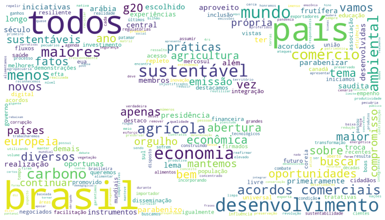

```python
# Criando o objeto wordcloud com as configs necessárias
wordcloud = WordCloud(stopwords=stopwords,
                      background_color='white', width=1600,
                      height=800, max_words=2000, mask=mask1, max_font_size=1000,
                      min_font_size=1).generate(doc)


#configurando forma de apresentação do gráfico e apresentando no notebook.
fig, ax = plt.subplots(figsize=(16,8))
ax.imshow(wordcloud, interpolation='bilinear')
ax.set_axis_off()
plt.imshow(wordcloud);
```

#### Exemplo 2

```python
# definindo uma imagem como máscara
mask2 = np.array(Image.open("images_preto_branco/brasilia.jpg"))
```

Para este exemplo, passamos uma parâmetro a mais que o *contour_width* que contorna o desenho formado e podemos escolher a cor que quisermos também.

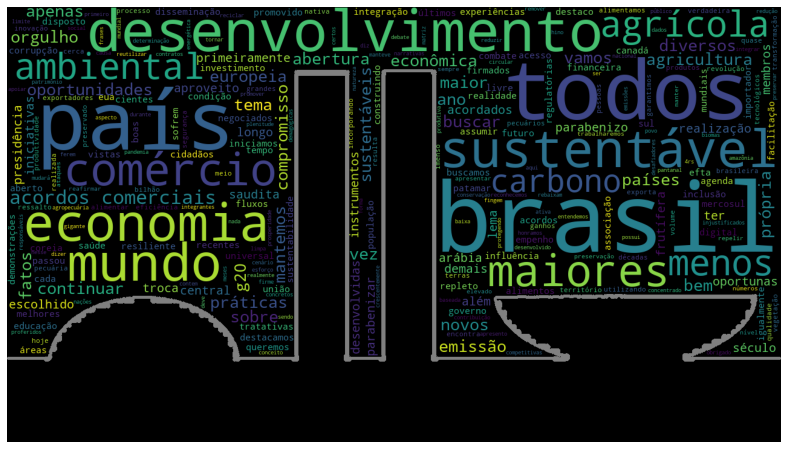

```python
# Criando o objeto wordcloud com as configs necessárias
wordcloud = WordCloud(stopwords=stopwords,
                      background_color='black', width=1600,
                      height=800, max_words=1000, mask=mask2, max_font_size=500,
                      min_font_size=1, contour_width=5, contour_color='gray').generate(doc)


#configurando forma de apresentação do gráfico e apresentando no notebook.
fig, ax = plt.subplots(figsize=(16,8))
ax.imshow(wordcloud, interpolation='bilinear')
ax.set_axis_off()
plt.imshow(wordcloud);
```

## Conclusão

O objetivo era demonstrar de forma fácil e rápido o uso para wordcloud, embora seja uma aplicação simples, também é customizável e vale a pena dar uma olhada na documentação e explorar outros recursos.

## Referências

WordCloud for Python documentation  
https://amueller.github.io/word_cloud/